# Questionnaire Report for Bluefin tuna

(MERA version 4.1.6)

Brett van Poorten (brett.vanpoorten@gmail.com)

2019-04-27

# 1 About this document

This is a prototype of an automatic report that documents how the user specified the operating model and their various justifications.

# 2 Introduction

1. Describe the history and current status of the fishery, including fleets, sectors, vessel types and practices/gear by vessel type, landing ports, economics/markets, whether targeted/bycatch, other stocks caught in the fishery. The bluefin tuna fishery is managed as two stocks; separated roughly by the 45th meridian, however genetic analysis and various tagging technologies indicate mixing. The population is targeted and incidentally caught primarily by multiple nations: Canada, Japan, Mexico, USA and Cuba. Vessel types include longline, other surf., purse seine, the sport fishery and traps. The population in the Western Atlantic seems much smaller than the east and was not generally commercially targeted until the early 1960s. Rapid increase in fishing caused catches to rapidly increase and then decline by the 1970s. Stricter regulations were put in place in the 1980s and a rebuilding plan was put in place in 1998. MSY for this population is relatively uncertain, so F0.1 is used as a proxy for FMSY. “The total catch for the West Atlantic peaked at 18,608 t in 1964, mostly due to the Japanese longline fishery for large fish off Brazil (that started in 1962) and the U.S. purse seine fishery for juvenile fish (BFTW- Figure 1). Catches dropped sharply thereafter to slightly above 3,000 t in 1969 with the collapse of the bluefin tuna by-catch longline fishery off Brazil in 1967 and declines in purse seine catches. Catches increased again to average over 5,000 t in the 1970s due to the expansion of the Japanese longline fleet into the northwest Atlantic and Gulf of Mexico and an increase in purse seine effort targeting larger fish for the sashimi market. Catches declined abruptly in 1982 from close to 6,000 t in the late 1970s early 1980s with the imposition of a quota. The total catch for the West Atlantic, including discards, fluctuated without trend after 1982 reaching 3,319 t in 2002 (the highest since 1981, with all three major fishing nations indicating higher catches). Total catch in the West Atlantic subsequently declined steadily to 1,638 t in 2007 and then fluctuated without pronounced trend (BFT-Table 1). The catch in 2015 was 1,842 t, 1,901 in 2016 and 1,851 t in 2017 (BFTW-Figure 1).” (bluefin summary report)
2. Describe the stock’s ecosystem functions, dependencies, and habitat types. “Atlantic bluefin tuna (BFT) have a wide geographical distribution but mainly live in the temperate pelagic ecosystem of the entire North Atlantic and its adjacent waters, for example the Gulf of Mexico, Gulf of St. Lawrence and the Mediterranean Sea. Historical catch information documented the presence in the south Atlantic however recent information is incomplete (BFT-Figure 1), Archival tagging information confirmed that bluefin tuna can tolerate cold as well as warm water temperatures while maintaining a stable internal body temperature. Bluefin tuna preferentially occupy the surface and subsurface waters of the coastal and open-sea areas, but archival tagging and ultrasonic telemetry data indicate that they frequently dive to depths of more than 1,000 m. Bluefin tuna are a highly migratory species that seems to display a homing behavior and spawning site fidelity to primary spawning areas in both the Mediterranean Sea and Gulf of Mexico. Evidence indicates that spawning has been observed in other areas for example the vicinity of the Slope Sea off the Northeast USA, though their persistence and importance remain to be determined. Electronic tagging is also resolving the movements to the foraging areas within the Mediterranean and the North Atlantic and indicate that bluefin tuna movement patterns vary by tagging site, by month of tagging and according to the age of the fish. The reappearance of bluefin tuna in historical fishing areas (e.g. northern waters and in the Black Sea) suggest that important changes in the spatial dynamics of bluefin tuna may also have resulted from interactions between biological factors, environmental variations and the reduction in fishing effort.” (Stock Assessment summary report.pdf) Bluefin are a top predator and therefore distribute themselves according to the distribution of their prey - in Canada that is primarily herring and mackerel. Recent shifts in prey distribution has pushed Bluefin further north.
3. Provide all relevant reference materials, such as assessments, research, and other analysis. Bluefin Tuna Detailed Stock Assessment Report.pdf Bluefin Tuna Summary Stock Assessment Report.pdf

# 3 Fishery Characteristics

## 3.1 Longevity

| Answered |
| --- |
| Very short-lived (5 < maximum age < 7) |
| Short-lived (7 < maximum age < 10) |
| Moderate life span (10 < maximum age < 20) |
| Moderately long-lived (20 < maximum age < 40) |
| Long-lived (40 < maximum age < 80) |
| Very long-lived (80 < maximum age < 160) |

| Justification |
| --- |
| “Bluefin tuna is a long-lived species, with a lifespan of about 40 years, as indicated by radiocarbon deposition and can reach 330 cm (SFL) and weigh up to 725 kg.” (summary report.pdf) |

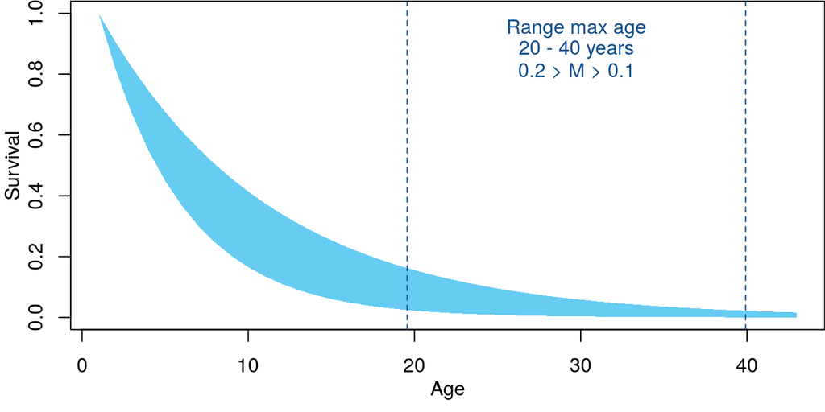

## 3.2 Stock depletion

| Answered |
| --- |
| Crashed (D < 0.05) |
| Very depleted (0.05 < D < 0.1) |
| Depleted (0.1 < D < 0.15) |
| Moderately depleted (0.15 < D < 0.3) |
| Healthy (0.3 < D < 0.5) |
| Underexploited (0.5 < D) |

| Justification |
| --- |
| Biomass estimates from SS3 indicate biomass is approximately 20% of unfished (Figure 4 of summary report: Biomass estimate.png) |

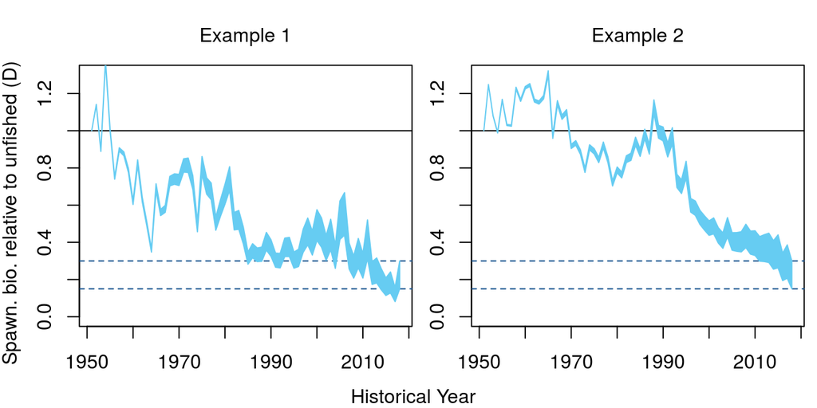

## 3.3 Resilence

| Answered |
| --- |
| Not resilient (steepness < 0.3) |
| Low resilience (0.3 < steepness < 0.5) |
| Moderate resilence (0.5 < steepness < 0.7) |
| Resilient (0.7 < steepness < 0.9) |
| Very Resilient (0.9 < steepness) |

[output not shown]

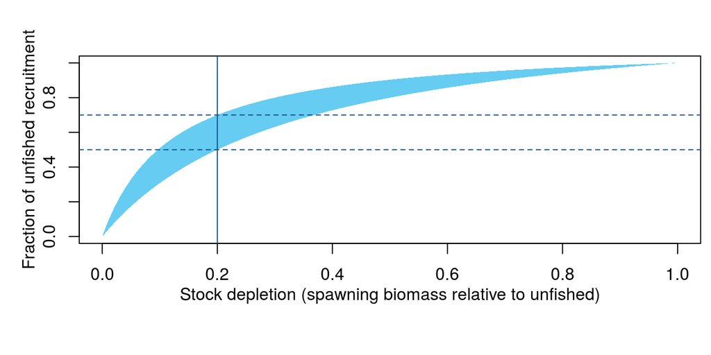

## 3.4 Historical effort pattern

| Answered |
| --- |
| Stable |
| Two-phase |
| Boom-bust |
| Gradual increases |
| Stable, recent increases |
| Stable, recent declines |

Justification

I could not find a time series of fishing effort, though the catch history indicates significant over investment in the 1960s, followed by collapse and increasing regulation (either on catch or effort). Best I could find: “The total catch for the West Atlantic peaked at 18,608 t in 1964, mostly due to the Japanese longline fishery for large fish off Brazil (that started in 1962) and the U.S. purse seine fishery for juvenile fish (BFTW- Figure 1). Catches dropped sharply thereafter to slightly above 3,000 t in 1969 with the collapse of the bluefin tuna by-catch longline fishery off Brazil in 1967 and declines in purse seine catches. Catches increased again to average over 5,000 t in the 1970s due to the expansion of the Japanese longline fleet into the northwest Atlantic and Gulf of Mexico and an increase in purse seine effort targeting larger fish for the sashimi market.” (summary report.pdf)

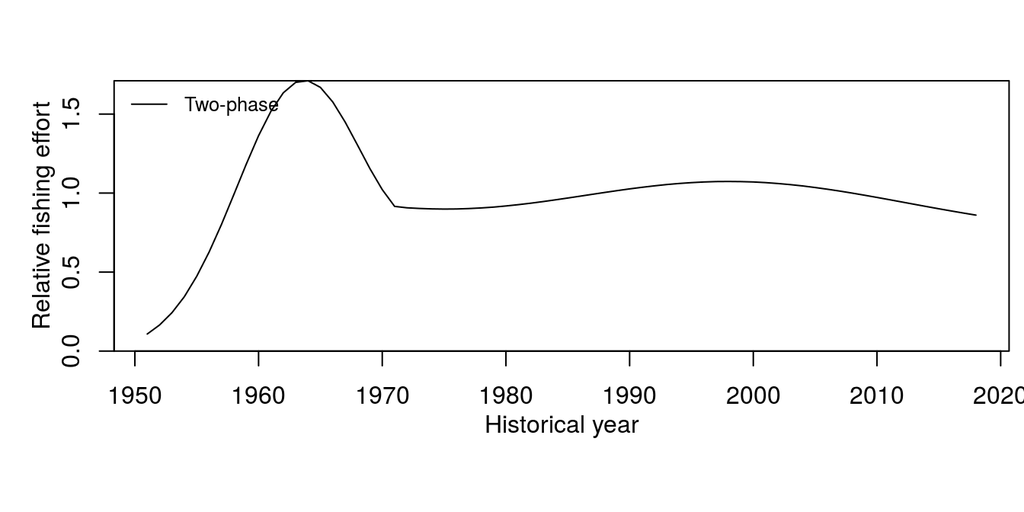

## 3.5 Inter-annual variability in historical effort

| Answered |
| --- |
| Not variable (less than 20% inter-annual change (IAC)) |
| Variable (maximum IAC between 20% to 50%) |
| Highly variable (maximum IAC between 50% and 100%) |

| Justification |
| --- |
| Variation in effort unknown |

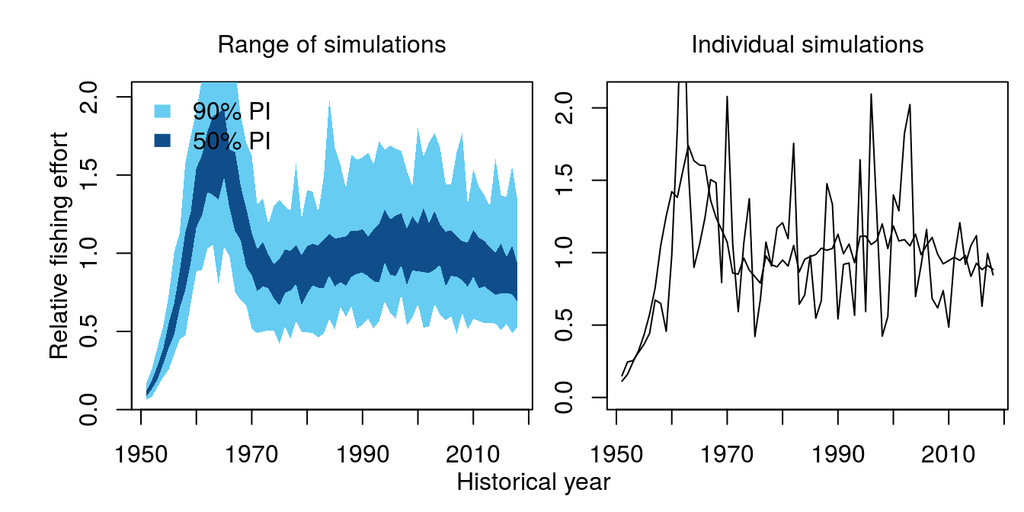

## 3.6 Historical fishing efficiency changes

| Answered |
| --- |
| Declining by 2-3% pa (halves every 25-35 years) |
| Declining by 1-2% pa (halves every 35-70 years) |
| Stable -1% to 1% pa (may halve/double every 70 years) |
| Increasing by 1-2% pa (doubles every 35-70 years) |
| Increasing by 2-3% pa (doubles every 25-35 years) |

| Justification |
| --- |
| No information on efficiency changes found. Increases in targeting and increasing importance of longline and purse seines suggest some increases, along with the expected changes in technology. |

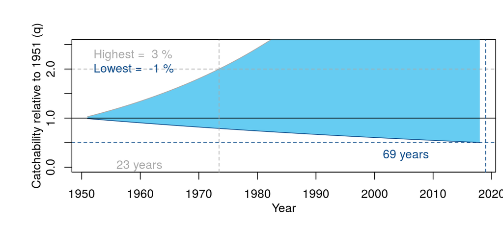

## 3.7 Future fishing efficiency changes

| Answered |
| --- |
| Declining by 2-3% pa (halves every 25-35 years) |
| Declining by 1-2% pa (halves every 35-70 years) |
| Stable -1% to 1% pa (may halve/double every 70 years) |
| Increasing by 1-2% pa (doubles every 35-70 years) |
| Increasing by 2-3% pa (doubles every 25-35 years) |

| Justification |
| --- |
| No changes anticipated considering stable management into the future. |

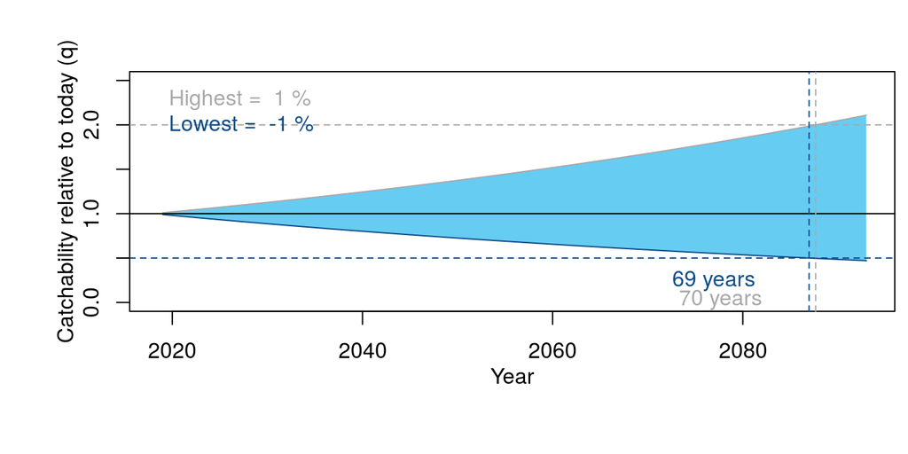

## 3.8 Length at maturity

| Answered |
| --- |
| Very small (0.4 < LM < 0.5) |
| Small (0.5 < LM < 0.6) |
| Moderate (0.6 < LM < 0.7) |
| Moderate to large (0.7 < LM < 0.8) |
| Large (0.8 < LM < 0.9) |

| Justification |
| --- |
| Age at maturity set either to age-5, consistent with observations in the Mediterranean, or age-15. |

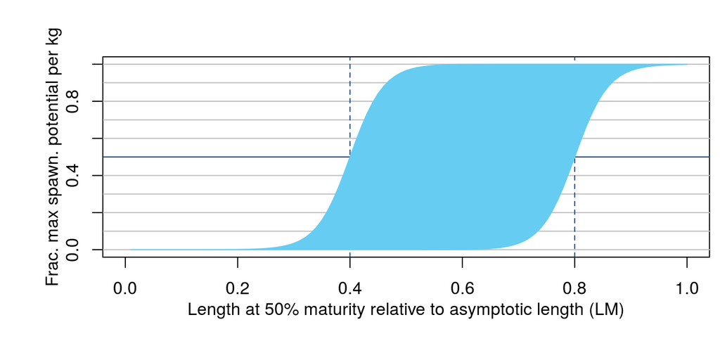

## 3.9 Selectivity of small fish

| Answered |
| --- |
| Very small (0.1 < S < 0.2) |
| Small (0.2 < S < 0.4) |
| Half asymptotic length (0.4 < S < 0.6) |
| Large (0.6 < S < 0.8) |
| Very large (0.8 < S < 0.9) |

[output not shown]

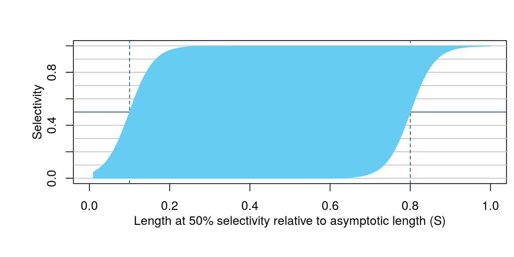

## 3.10 Selectivity of large fish

| Answered |
| --- |
| Asymptotic selectivity (SL = 1) |
| Declining selectivity with length (0.75 < SL < 1) |
| Dome-shaped selectivity (0.25 < SL < 0.75) |
| Strong dome-shaped selectivity (SL < 0.25) |

| Justification |
| --- |
| Descending limb also quite variable across fleets (see Bluefin selectivity.pgn; figure 35 in detailed stock assessment report) |

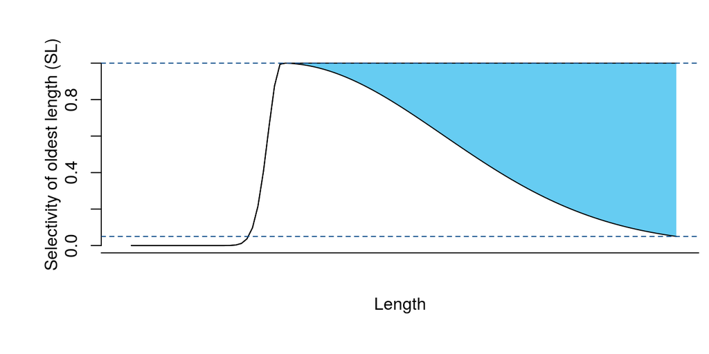

## 3.11 Discard rate

| Answered |
| --- |
| Low (DR < 1%) |
| Low - moderate (1% < DR < 10%) |
| Moderate (10% < DR < 30%) |
| Moderate - high (30% < DR < 50%) |
| High (50% < DR < 70%) |

[output not shown]

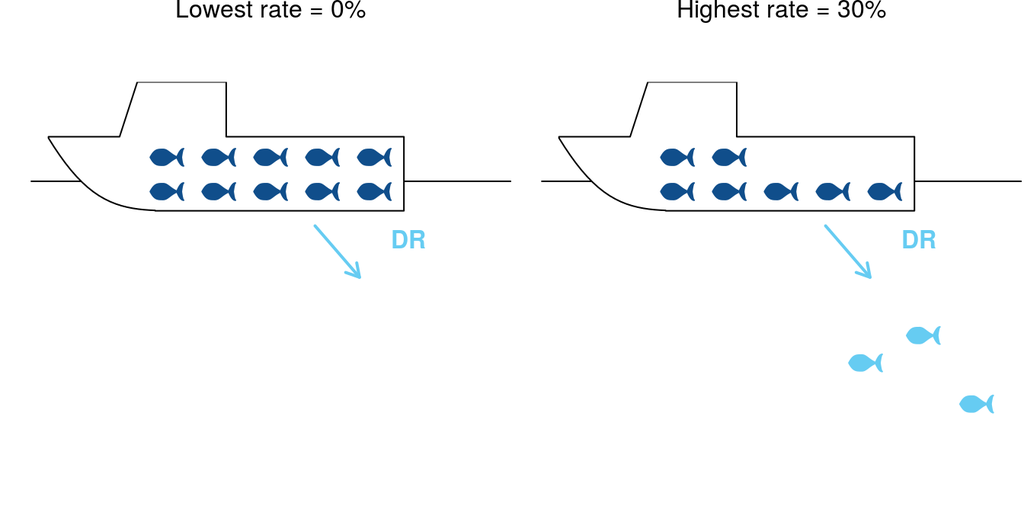

## 3.12 Post-release mortality rate

| Answered |
| --- |
| Low (PRM < 5%) |
| Low - moderate (5% < PRM < 25%) |
| Moderate (25% < PRM < 50%) |
| Moderate - high (50% < PRM < 75%) |
| High (75% < PRM < 95%) |
| Almost all die (95% < PRM < 100%) |

Justification

angling release mortality: “Skomal et al. (2002) estimated that release mortality would have occurred in 4% of the bluefin tuna caught on circle hooks and 28% caught on J hooks based on the frequency and extent of observed hook damage.” (Skomal 2007 - referring to Skomal G., Chase B. & Prince E.D. (2002) A comparison of circle hook and straight hook performance in recreational fisheries for juvenile Atlantic bluefin tuna. In: J.A. Lucy & A.L. Studholme (eds) Catch and Release in Marine Recreational Fisheries. Bethesda, MD, USA: American Fisheries Society, Symposium 30, pp. 57–65.)  
Nothing else was found for other methods

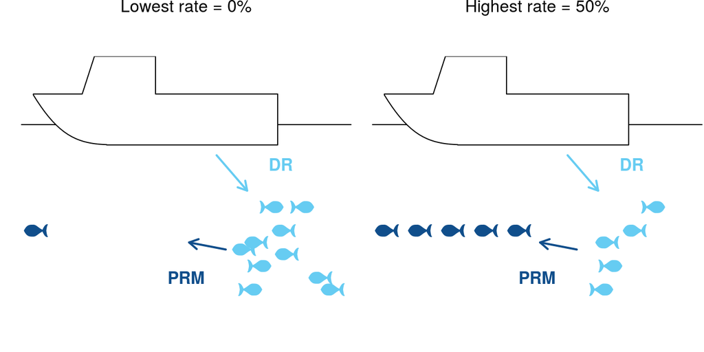

## 3.13 Recruitment variability

| Answered |
| --- |
| Very low (less than 10% inter-annual changes (IAC)) |
| Low (max IAC of between 20% and 60%) |
| Moderate (max IAC of between 60% and 120%) |
| High (max IAC of between 120% and 180%) |
| Very high (max IAC greater than 180%) |

| Justification |
| --- |
| Back-calculated recruitment (from VPA) seems quite stable (see Bluefin recruitment2.png and Bluefin stock recruitment.png). |

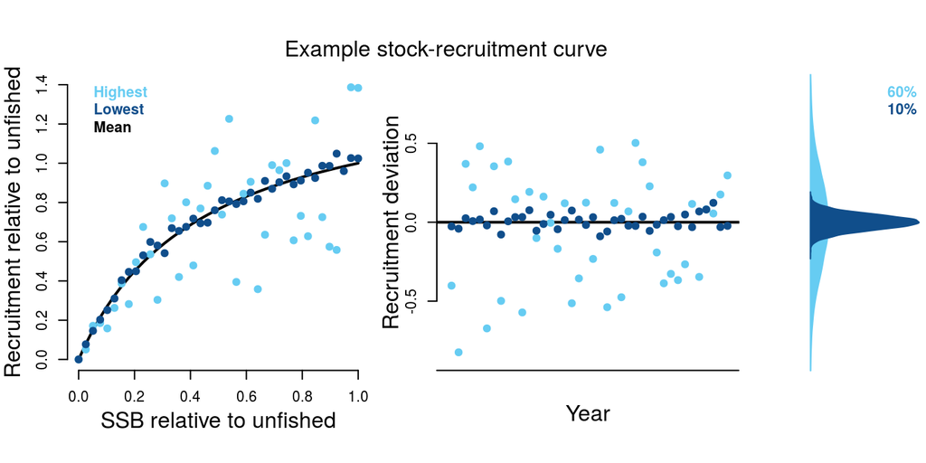

## 3.14 Size of an existing MPA

| Answered |
| --- |
| None |
| Small (A < 5%) |
| Small-moderate (5% < A < 10%) |
| Moderate (10% < A < 20%) |
| Large (20% < A < 30%) |
| Very large (30% < A < 40%) |
| Huge (40% < A < 50%) |

| Justification |
| --- |
| I could not find any indication that there are any spatial closures in place |

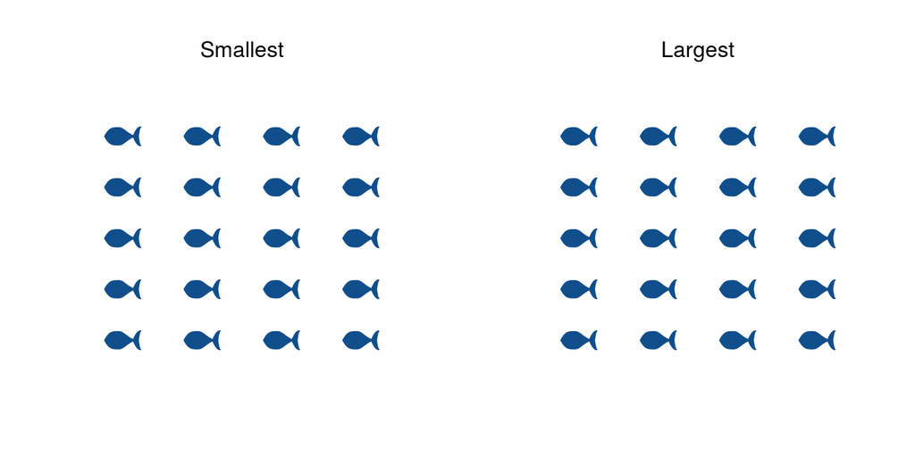

## 3.15 Spatial mixing (movement) in/out of existing MPA

| Answered |
| --- |
| Very low (P < 1%) |
| Low (1% < P < 5%) |
| Moderate (5% < P < 10%) |
| High (10% < P < 20%) |
| Fully mixed |

| Justification |
| --- |
| This is a highly migratory species. Any restriction in mixing would only come because spawning areas are protected. |

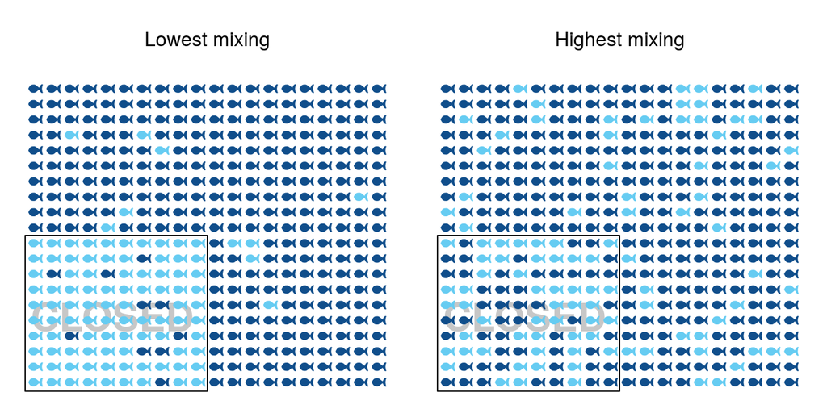

## 3.16 Size of a future potential MPA

| Answered |
| --- |
| None |
| Small (A < 5%) |
| Small-moderate (5% < A < 10%) |
| Moderate (10% < A < 20%) |
| Large (20% < A < 30%) |
| Very large (30% < A < 40%) |
| Huge (40% < A < 50%) |

| Justification |
| --- |
| Pew suggested closing areas of the Gulf of Mexico to fishing to protect spawning grounds (Pew 2010). |

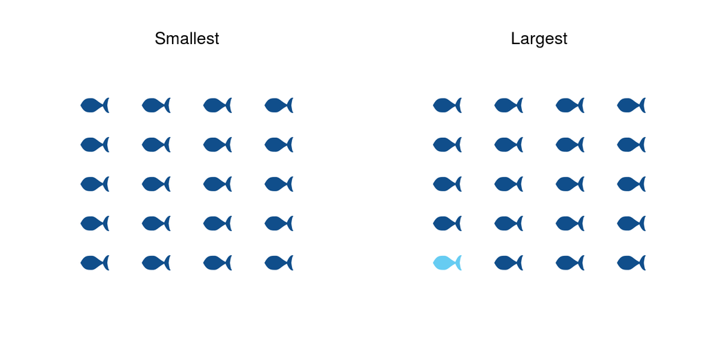

## 3.17 Spatial mixing (movement) in/out of future potential MPA

| Answered |
| --- |
| Very low (P < 1%) |
| Low (1% < P < 5%) |
| Moderate (5% < P < 10%) |
| High (10% < P < 20%) |
| Fully mixed |

| Justification |
| --- |
| This is a highly migratory species. Any restriction in mixing would only come because spawning areas are protected. |

[figure not shown]

## 3.18 Initial stock depletion

| Answered |
| --- |
| Very low (0.1 < D1 < 0.15) |
| Low (0.15 < D1 < 0.3) |
| Moderate (0.3 < D < 0.5) |
| High (0.5 < D1) |
| Asymptotic unfished levels (D1 = 1) |

[output not shown]

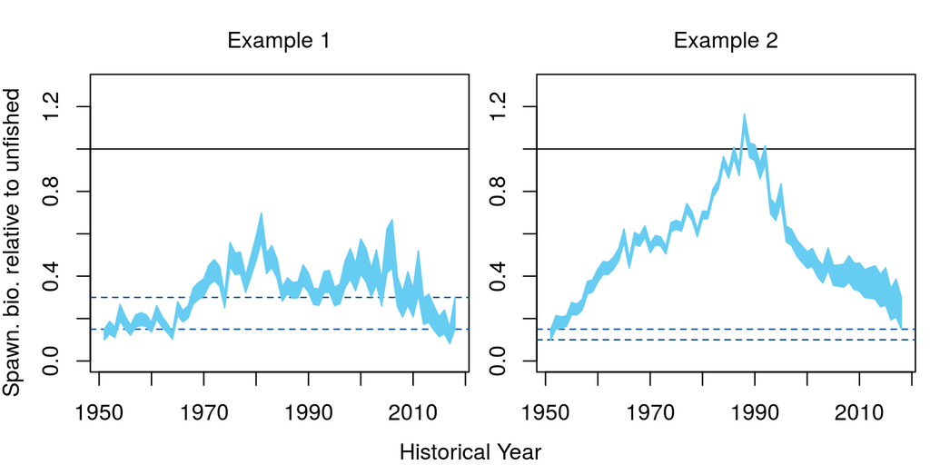

# 4 Management Characteristics

## 4.1 Types of fishery management that are possible

| Answered |
| --- |
| TAC (Total Allowable Catch): a catch limit |
| TAE (Total Allowable Effort): an effort limit |
| Size limit |
| Time-area closures (a marine reserve) |

Justification

1. Describe what, if any, current management measures are used to constrain catch/effort.  
Individual countries have specific regulations. ICCAT sets TAC each year for each country and individual countries decide how to implement and distribute this. In Canada, individual fleets have different operating seasons. The TAC is distributed among fleets based on average historical landings. Minimum size limits of 6.4 kg were  
implemented in 1974 and continued with new 1981 regulations. Closures of the Gulf of Mexico during spawning were started in 1986 and continued until 1990; they were re-implemented in 1998 under the rebuilding plan. (Canadian Atlantic Bluefin Tuna Integrated Management Plan: http://www.dfo-mpo.gc.ca/fm-gp/peches-fisheries/ifmp-gmp/bluefin-tuna-thon-rouge/bluefin-tuna-thonrouge2017-eng.htm)  
In the US: “This final rule implements Amendment 7 to the 2006 Consolidated Atlantic Highly Migratory Species Fishery Management Plan (2006 Consolidated HMS FMP) to ensure sustainable management of bluefin tuna consistent with the 2006 HMS FMP and address ongoing management challenges in the Atlantic bluefin tuna fisheries. This final rule also implements minor regulatory changes related to the management of Atlantic HMS. Amendment 7 management measures were developed by NMFS under the authority of the Magnuson-Stevens Fishery Conservation and Management Act (Magnuson-Stevens Act) and the Atlantic Tunas Convention Act (ATCA). This final rule: Allocates U.S. bluefin tuna quota among domestic fishing categories; implements measures applicable to the pelagic longline fishery, including Individual Bluefin Quotas (IBQs), two new Gear Restricted Areas, closure of the pelagic longline fishery when annual bluefin tuna quota is reached, elimination of target catch requirements associated with retention of incidental bluefin tuna in the pelagic longline fishery, mandatory retention of legal-sized bluefin tuna caught as bycatch, expanded monitoring requirements, including electronic monitoring via cameras and bluefin tuna catch reporting via Vessel Monitoring System (VMS), and transiting provisions for pelagic and bottom longline vessels; requires VMS use and reporting by the Purse Seine category; changes the start date of the Purse Seine category from July 15 to a date within a range of June 1 to August 15, to be established by an annual action; requires use of the Automated Catch Reporting System by the General and Harpoon categories; provides additional flexibility for inseason adjustment of the General category quota and Harpoon category retention limits; and changes the allocation of the Angling category Trophy South subquota for the Gulf of Mexico. Finally, this rule implements several measures not directly related to bluefin tuna management, including a U.S. North Atlantic albacore tuna quota; modified rules regarding permit category changes; and minor changes in the HMS regulations for administrative or clarification purposes.” (Amendment 7: NOAA Fisheries Management Plan: https://www.federalregister.gov/documents/2014/12/02/2014-28064/atlantic-highly-migratory-species-2006-consolidated-atlantic-highly-migratory-species-hms-fishery)  
2. Describe historical management measures, if any.  
“While some of the initial concerns which led to the creation of ICCAT stemmed from the eastern Atlantic, it was the western Atlantic where management measures were first concentrated, given longline and purse seine catches had both increased from around 100t each in the late 1950s to 12,000t and 5,000t respectively in 1964. The 1981 Recommendation [Rec. 81-01] set out specific requirements for the western Atlantic Bluefin stock, including a total allowable catch limit, and continued the 1974 minimal size limit of 6.4 kg for all Bluefin tuna. New Regulations for the Atlantic Bluefin Tuna Catch [1983] [82-01], pertaining again mainly to Bluefin tuna fisheries in the western Atlantic, were adopted in 1982. These regulations continued with gradual refinements until 1986, by which time the measures included a closure of the fishery during the spawning season in the Gulf of Mexico and additional requirements in relation to minimum size. These measures were extended annually by the Commission until 1990.  
In 1991, the Commission adopted the Recommendation by ICCAT for the Enhancement of the Current Management of Western Atlantic Bluefin Tuna [Rec. 91-01], which specified the individual country catch limits in the body of the text for the first time. It also agreed to proceed to tag all Atlantic Bluefin tuna harvested and available for sale and implement a system whereby the import of all Bluefin tuna had to be accompanied by a certificate of origin. In 1992 the Commission adopted the Recommendation by ICCAT Concerning the ICCAT Bluefin Tuna Statistical Document Program [Rec. 92-01], which required all imported Bluefin tuna to be accompanied by an ICCAT Statistical Document, with the double aim of estimating the real level of catches and reducing catches taken in a manner which could undermine the ICCAT conservation and management measures.  
In 1998, recognising that the western stock of Bluefin tuna was over-exploited, the Commission adopted a twenty-year rebuilding plan which began in 1999. The plan set a Total Allowable Catch (TAC) that was modifiable in accordance with scientific advice, a closed area during the spawning season in the Gulf of Mexico, and a sharing arrangement based on percentage shares of the TAC. A new measure, adopted in 2008, further reduced the TAC of western Atlantic Bluefin tuna. Between 2007 and 2017, the TAC has been established at levels to promote the rebuilding of the stock. The TAC was increased to 2000t in 2015 and further increased to 2350t per year for the 2018-2020 seasons due to positive results of the 2017 stock assessment (see Table 1).” (Canadian Atlantic Bluefin Tuna Integrated Management Plan: http://www.dfo-mpo.gc.ca/fm-gp/peches-fisheries/ifmp-gmp/bluefin-tuna-thon-rouge/bluefin-tuna-thonrouge2017-eng.htm)  
3. Describe main strengths and weaknesses of current monitoring and enforcement capacity.  
Fisheries monitoring includes tagging all harvested tuna, dockside monitoring, logbooks and onboard observers. No issues with monitoring or enforcement are noted.  
4. Describe and reference any legal/policy requirements for management, monitoring and enforcement.  
references provided above:  
Canadian Atlantic Bluefin Tuna (thunnus thynnus)- NAFO Fishing Areas 3KLNOP, 4RSTVWX and 5YZ - 2017: http://www.dfo-mpo.gc.ca/fm-gp/peches-fisheries/ifmp-gmp/bluefin-tuna-thon-rouge/bluefin-tuna-thonrouge2017-eng.htm  
NOAA Consolidated Atlantic Highly Migratory Species Management Plan: https://www.fisheries.noaa.gov/management-plan/consolidated-atlantic-highly-migratory-species-management-plan

## 4.2 TAC offset: consistent overages/underages

| Answered |
| --- |
| Large underages (40% - 70% of recommended) |
| Underages (70% - 90% of recommended) |
| Slight underages (90% - 100% of recommended) |
| Taken exactly (95% - 105% of recommended) |
| Slight overages (100% - 110% of recommended) |
| Overages (110% - 150% of recommended) |
| Large overages (150% - 200% of recommended) |

| Justification |
| --- |
| See Catch History.pdf |

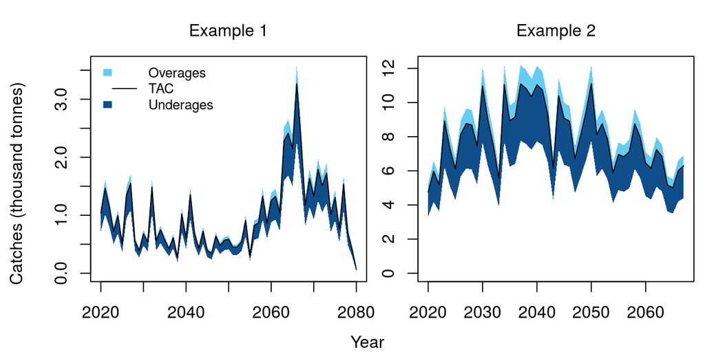

## 4.3 TAC implementation variability

| Answered |
| --- |
| Constant (V < 1%) |
| Not variable (1% < V < 5%) |
| Low variability (5% < V < 10%) |
| Variable (10% < V < 20%) |
| Highly variable (20% < V < 40%) |

[output not shown]

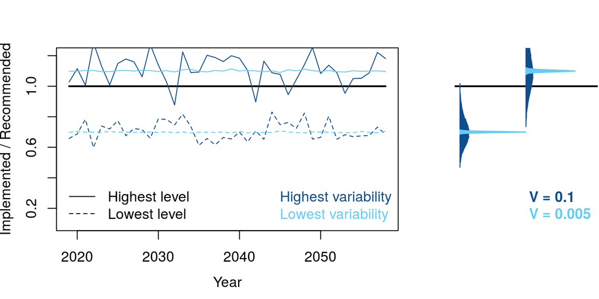

## 4.4 TAE offset: consistent overages/underages

| Answered |
| --- |
| Large underages (40% - 70% of recommended) |
| Underages (70% - 90% of recommended) |
| Slight underages (90% - 100% of recommended) |
| Taken exactly (95% - 105% of recommended) |
| Slight overages (100% - 110% of recommended) |
| Overages (110% - 150% of recommended) |
| Large overages (150% - 200% of recommended) |

| Justification |
| --- |
| There are no real TAEs implemented, although fisheries (particularly longline) are closed once TAC is reached. |

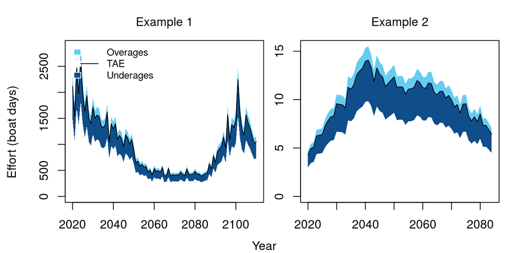

## 4.5 TAE implementation variability

| Answered |
| --- |
| Constant (V < 1%) |
| Not variable (1% < V < 5%) |
| Low variability (5% < V < 10%) |
| Variable (10% < V < 20%) |
| Highly variable (20% < V < 40%) |

| Justification |
| --- |
| TAEs not really implemented. A fixed number of licences are allowed by each country, but not sure if this is limited specifically to regulate the fishery or not. |

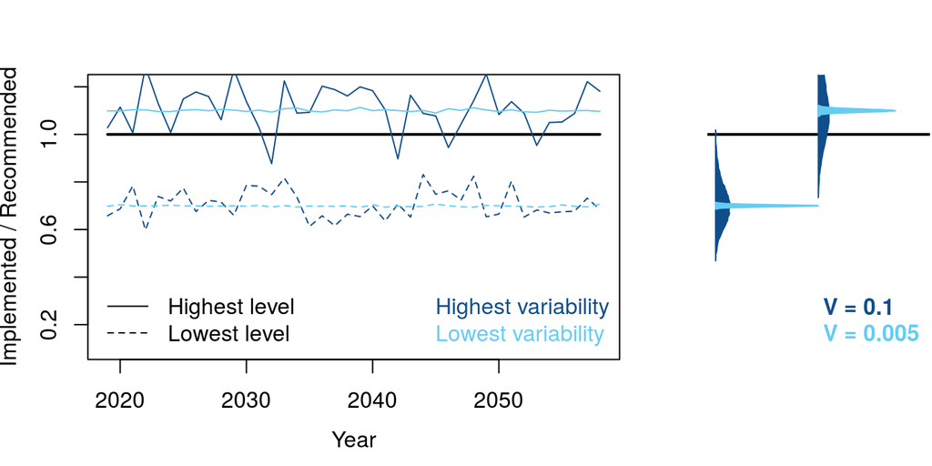

## 4.6 Size limit offset: consistent overages/underages

| Answered |
| --- |
| Much smaller (40% - 70% of recommended) |
| Smaller (70% - 90% of recommended) |
| Slightly smaller (90% - 100% of recommended) |
| Taken exactly (95% - 105% of recommended) |
| Slightly larger (100% - 110% of recommended) |
| Larger (110% - 150% of recommended) |
| Much larger (150% - 200% of recommended) |

[output not shown]

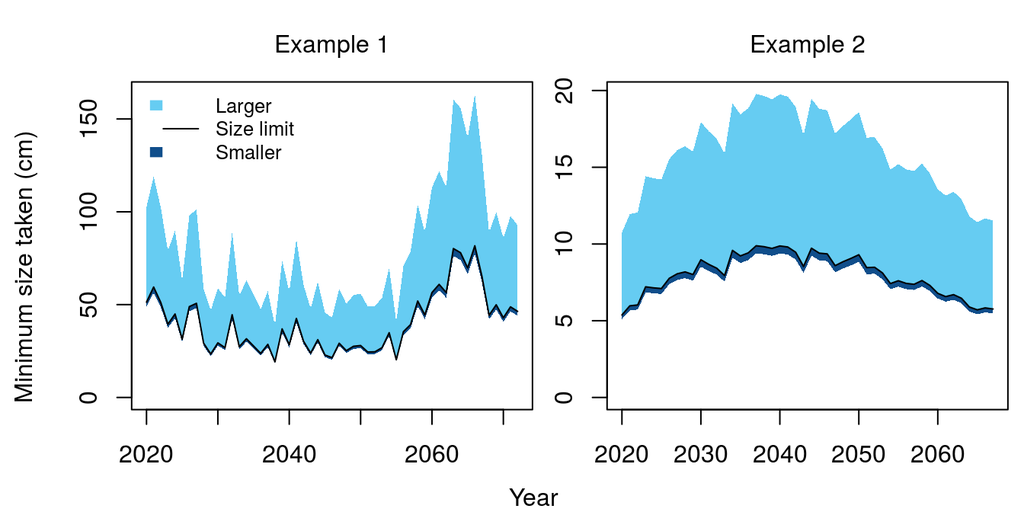

## 4.7 Size limit implementation variability

| Answered |
| --- |
| Constant (V < 1%) |
| Not variable (1% < V < 5%) |
| Low variability (5% < V < 10%) |
| Variable (10% < V < 20%) |
| Highly variable (20% < V < 40%) |

| Justification |
| --- |
| No change in size limits over time. |

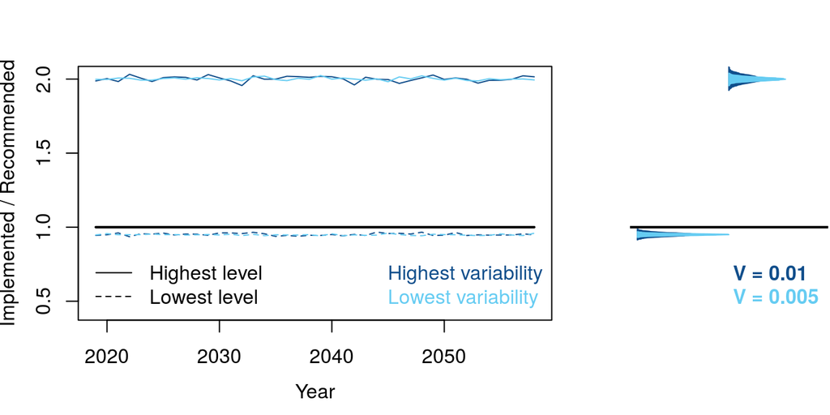

# 5 Data Characteristics

## 5.1 Available data types

| Answered |
| --- |
| Historical annual catches (from unfished) |
| Recent annual catches (at least 5 recent years) |
| Historical relative abundance index (from unfished) |
| Recent relative abundance index (at least 5 recent years) |
| Fishing effort |
| Size composition (length samples) |
| Age composition (age samples) |
| Growth (growth parameters) |
| Absolute biomass survey |

Justification

1. Provide the time series (specify years, if possible) that exist for catch, effort, and CPUE/abundance indices.  
Historical catch: Table 2 of detailed stock assessment  
Recent catch: Table 2 of detailed stock assessment  
Recent relative index (since 1974): Table 9 of detailed stock assessment  
Size composition (since 1961): Figure 4 of detailed stock assessment  
Age composition (since 1970): Figure 5 of detailed stock assessment  
Growth parameters based from Cort 1991: described in Table 1 of detailed stock assessment  
2. Describe how these data collected (e.g., log books, dealer reporting, observers).  
Each individual fish is tagged prior to going to market  
Individual archival and telemetry data is used to estimate mixing rates, though these rates do not seem to play a role in the assessment. Otolith microchemistry is used for same.  
Tagging data used to resolve natural mortality  
3. Describe what types of sampling programs and methodologies exist for data collection, including the time-series of available sampling data and quality.  
No information could be found on the sampling programs of different countries.  
4. Describe all sources of uncertainty in the status, biology, life history and data sources of the fishery. Include links to documentation, reports.  
Age at maturity was unknown (There are also indications that some young individuals (age 5) of unknown origin caught in the West Atlantic were mature, but there was considerable uncertainty with regards to their contribution to the western stock spawning. Therefore, for the western stock the SCRS considered two spawning schedules; one identical to that used for the East and one with peak spawning at age 15.: https://www.iccat.int/Documents/SCRS/ExecSum/BFT_ENG.pdf)  
“The SCRS cautions that conclusions from the latest assessment (2017), using data through 2015, do not capture the full degree of uncertainty in the assessments and projections. The various major contributing factors to these uncertainties include mixing between the stocks, recruitment, age composition, age at maturity, and indices of abundance.: https://www.iccat.int/Documents/SCRS/ExecSum/BFT_ENG.pdf)  
Mixing contribution from the eastern stock is uncertain:”The Committee reiterates that the effects of mixing and management measures on the eastern stock remains a considerable source of uncertainty for the outlook of the western stock." (https://www.iccat.int/Documents/SCRS/ExecSum/BFT_ENG.pdf)

## 5.2 Catch reporting bias

| Answered |
| --- |
| Strong under-reporting (30% - 50%) |
| Under-reporting (10% - 30%) |
| Slight under-reporting (less than 10%) |
| Reported accurately (+/- 5%) |
| Slight over-reporting (less than 10%) |

[output not shown]

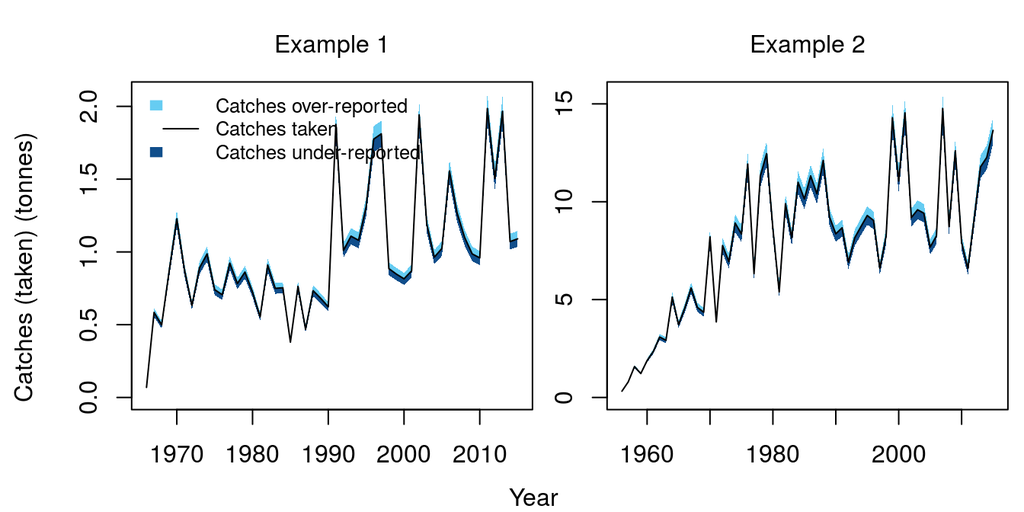

## 5.3 Hyperstability in indices

| Answered |
| --- |
| Strong hyperdepletion (2 < Beta < 3) |
| Hyperdepletion (1.25 < Beta < 2) |
| Proportional (0.8 < Beta < 1.25) |
| Hyperstability (0.5 < Beta < 0.8) |
| Strong hyperstability (0.33 < Beta < 0.5) |

| Justification |
| --- |
| Hyperstability is possible, and discussed as a potential factor in their CPUE standardization (https://iccat.int/Documents/Meetings/Docs/2017_BFT_DATA_PREP_ENG.pdf) |

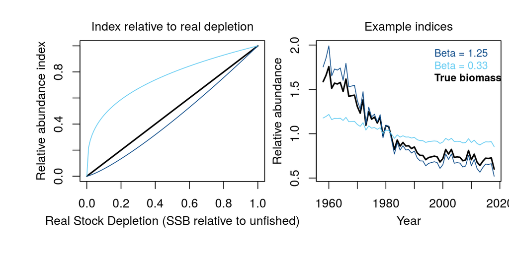

| Answered |
| --- |
| Perfect |
| Good (accurate and precise) |
| Data moderate (some what inaccurate and imprecise) |
| Data poor (inaccurate and imprecise) |

Justification

annual catches and abundance indices appear good (no underreporting detected), but fish are notoriously difficult to age and differences in growth rates between cohorts are worrisome (“Authors raised concern that variability in size at age between cohorts might negatively affect age readings and ALKs.” https://iccat.int/Documents/Meetings/Docs/2017_BFT_DATA_PREP_ENG.pdf).

# 6 Version Notes

The package is subject to ongoing testing. If you find a bug or a problem please send a report to t.carruthers@oceans.ubc.ca so that it can be fixed!

shiny-2019-04-27-18:29:52

Open Source, GPL-2 2019